# **Computer Vision Project : Pneumonia Detecion Challenge**

## **Problem Statements**

### **Context**

Pneumonia is a serious respiratory infection characterized by inflammation of the lungs, which can be life-threatening if not detected and treated early. Traditionally, diagnosis is performed by radiologists through careful examination of chest X-ray images. However, manual diagnosis is time-consuming, subjective, and prone to inter-observer variability, especially when there are a large number of cases to evaluate.

With the advancement of computer vision and deep learning techniques, automated analysis of chest radiographs has become feasible. In this project, the objective is to build an algorithm that can automatically detect pneumonia in chest X-rays by identifying lung opacities — the visual signals of pneumonia. The system must not only predict the presence of pneumonia but also provide bounding boxes around the affected lung regions, thereby assisting radiologists with faster and more accurate diagnosis.

This problem falls within the healthcare domain and is a classic computer vision detection task, requiring both classification (pneumonia vs. non-pneumonia) and localization (drawing bounding boxes).

**Locate lung opacities on chest radiographs**

### **Data Description**

The dataset is derived from the RSNA Pneumonia Detection Challenge and is provided in DICOM format, the standard for medical imaging. It consists of chest radiographs and associated metadata for both training and testing.

**Files provided:**

- stage_2_train_images.zip – Training chest X-ray images in DICOM format.
- stage_2_test_images.zip – Test set images for evaluation.
- stage_2_train_labels.csv – Contains patient IDs, bounding box coordinates, and target labels.
- stage_2_detailed_class_info.csv – Provides detailed information about positive (pneumonia) and negative (non-pneumonia) classes.
- stage_2_sample_submission.csv – A template showing the required submission format.

**Data fields in stage_2_train_labels.csv:**

- patientId – Unique identifier for each patient/image.
- x – Upper-left x-coordinate of the bounding box.
- y – Upper-left y-coordinate of the bounding box.
- width – Width of the bounding box.
- height – Height of the bounding box.

**Target – Binary label:**

- 1 if pneumonia is present (bounding boxes provided),
- 0 if no evidence of pneumonia.

**Notes:**

- Each patientId corresponds to one chest X-ray.
- There may be multiple bounding boxes per image if multiple opacities are present.
- Images with Target = 0 do not have bounding boxes (no pneumonia).

**Predictions must follow the following format:**

- patientId, (if no pneumonia predicted),
- or patientId, confidence x y w h [confidence x y w h ...] for one or more bounding boxes.

## **Installing and Importing Necessary Libraries**

```python
!pip install pydicom
```

```
Downloading pydicom-3.0.1-py3-none-any.whl (2.4 MB)
   ━━━━━━━━━━━━━━━━━━━━━━━━━━━━━━━━━━━━━━━━ 2.4/2.4 MB 35.7 MB/s eta 0:00:00
```

```python
import numpy as np
import pandas as pd
from pathlib import Path
import zipfile
import random
from io import BytesIO
import pydicom
import matplotlib.pyplot as plt
from collections import defaultdict
import cv2
import os

from sklearn.model_selection import train_test_split

import tensorflow as tf
from tensorflow.keras.models import Sequential
from tensorflow.keras.layers import Conv2D, MaxPooling2D, Flatten, Dense, Dropout
from tensorflow.keras.optimizers import Adam
```

## **Step 1:** **Loading the Data**

```python
from google.colab import drive
drive.mount('/content/drive')
```

```python
# Paths
data_dir = Path("/content/drive/MyDrive/Capstone_Project/CV1_Pneumonia_Detection")

# CSVs
class_info_df = pd.read_csv(data_dir / "stage_2_detailed_class_info.csv")
labels_df = pd.read_csv(data_dir / "stage_2_train_labels.csv")
sample_sub_df = pd.read_csv(data_dir / "stage_2_sample_submission.csv")

# Preview
print("Class Info:\n", class_info_df.head(), "\n")
print("Train Labels:\n", labels_df.head(), "\n")
print("Sample Submission:\n", sample_sub_df.head())

#zip file
train_zip_path = data_dir / "stage_2_train_images.zip"
test_zip_path  = data_dir / "stage_2_test_images.zip"
```

```
Class Info:
                               patientId                         class
0  0004cfab-14fd-4e49-80ba-63a80b6bddd6  No Lung Opacity / Not Normal
1  00313ee0-9eaa-42f4-b0ab-c148ed3241cd  No Lung Opacity / Not Normal
2  00322d4d-1c29-4943-afc9-b6754be640eb  No Lung Opacity / Not Normal
3  003d8fa0-6bf1-40ed-b54c-ac657f8495c5                        Normal
4  00436515-870c-4b36-a041-de91049b9ab4                  Lung Opacity

Train Labels:
                               patientId      x      y  width  height  Target
0  0004cfab-14fd-4e49-80ba-63a80b6bddd6    NaN    NaN    NaN     NaN       0
1  00313ee0-9eaa-42f4-b0ab-c148ed3241cd    NaN    NaN    NaN     NaN       0
2  00322d4d-1c29-4943-afc9-b6754be640eb    NaN    NaN    NaN     NaN       0
3  003d8fa0-6bf1-40ed-b54c-ac657f8495c5    NaN    NaN    NaN     NaN       0
4  00436515-870c-4b36-a041-de91049b9ab4  264.0  152.0  213.0   379.0       1

Sample Submission:
                               patientId PredictionString
0  0000a175-0e68-4ca4-b1af-167204a7e0bc  0.5 0 0 100 100
1  0005d3cc-3c3f-40b9-93c3-46231c3eb813  0.5 0 0 100 100
2  000686d7-f4fc-448d-97a0-44fa9c5d3aa6  0.5 0 0 100 100
3  000e3a7d-c0ca-4349-bb26-5af2d8993c3d  0.5 0 0 100 100
4  00100a24-854d-423d-a092-edcf6179e061  0.5 0 0 100 100
```

## **Step 2: Map Training And Testing Images To Its Classes**

```python
# Train image → class mapping
train_image_class_map = dict(zip(class_info_df["patientId"], class_info_df["class"]))

# Test image → Unknown (no ground truth)
test_image_class_map = {pid: "Unknown" for pid in sample_sub_df["patientId"]}

# Example check
print("Sample train class map:", list(train_image_class_map.items())[:5])
print("\nSample test class map:", list(test_image_class_map.items())[:5])
```

```
Sample train class map: [('0004cfab-14fd-4e49-80ba-63a80b6bddd6', 'No Lung Opacity / Not Normal'), ('00313ee0-9eaa-42f4-b0ab-c148ed3241cd', 'No Lung Opacity / Not Normal'), ('00322d4d-1c29-4943-afc9-b6754be640eb', 'No Lung Opacity / Not Normal'), ('003d8fa0-6bf1-40ed-b54c-ac657f8495c5', 'Normal'), (…

Sample test class map: [('0000a175-0e68-4ca4-b1af-167204a7e0bc', 'Unknown'), ('0005d3cc-3c3f-40b9-93c3-46231c3eb813', 'Unknown'), ('000686d7-f4fc-448d-97a0-44fa9c5d3aa6', 'Unknown'), ('000e3a7d-c0ca-4349-bb26-5af2d8993c3d', 'Unknown'), ('00100a24-854d-423d-a092-edcf6179e061', 'Unknown')]
```

### **Observations:**

- Each training image was successfully mapped to its ground-truth class label (e.g., Normal, Lung Opacity, No Lung Opacity/Not Normal).
- Test images were mapped with "Unknown" since no labels are provided for evaluation.

## **Step 3: Map Training And Testing Images To Its Annotations**

```python
# Train image → list of bounding boxes
train_image_ann_map = defaultdict(list)
for _, row in labels_df.iterrows():
    pid = row["patientId"]
    if row["Target"] == 1:  # pneumonia positive
        box = [row["x"], row["y"], row["width"], row["height"]]
        train_image_ann_map[pid].append(box)

# Test images → no annotations
test_image_ann_map = {pid: [] for pid in sample_sub_df["patientId"]}

# Example check
sample_pid = list(train_image_ann_map.keys())[0]
print(f"Annotations for a Train Image {sample_pid}:", train_image_ann_map[sample_pid])

sample_pid = list(test_image_ann_map.keys())[0]
print(f"\nAnnotations for a Test Image {sample_pid}:", test_image_ann_map[sample_pid])
```

```
Annotations for a Train Image 00436515-870c-4b36-a041-de91049b9ab4: [[264.0, 152.0, 213.0, 379.0], [562.0, 152.0, 256.0, 453.0]]

Annotations for a Test Image 0000a175-0e68-4ca4-b1af-167204a7e0bc: []
```

### **Observations:**

- Training images with lung opacity were mapped to bounding-box annotations specifying affected regions.
- Test images have empty annotation lists since ground-truth bounding boxes are not available.

## **Step 4.1: Data Preprocessing**

### **Checking The Data Types Of The Columns For The Dataset**

```python
class_info_df.info()
```

```
<class 'pandas.core.frame.DataFrame'>
RangeIndex: 30227 entries, 0 to 30226
Data columns (total 2 columns):
 #   Column     Non-Null Count  Dtype
---  ------     --------------  -----
 0   patientId  30227 non-null  object
 1   class      30227 non-null  object
dtypes: object(2)
memory usage: 472.4+ KB
```

```python
labels_df.info()
```

```
<class 'pandas.core.frame.DataFrame'>
RangeIndex: 30227 entries, 0 to 30226
Data columns (total 6 columns):
 #   Column     Non-Null Count  Dtype
---  ------     --------------  -----
 0   patientId  30227 non-null  object
 1   x          9555 non-null   float64
 2   y          9555 non-null   float64
 3   width      9555 non-null   float64
 4   height     9555 non-null   float64
 5   Target     30227 non-null  int64
dtypes: float64(4), int64(1), object(1)
memory usage: 1.4+ MB
```

```python
sample_sub_df.info()
```

```
<class 'pandas.core.frame.DataFrame'>
RangeIndex: 3000 entries, 0 to 2999
Data columns (total 2 columns):
 #   Column            Non-Null Count  Dtype
---  ------            --------------  -----
 0   patientId         3000 non-null   object
 1   PredictionString  3000 non-null   object
dtypes: object(2)
memory usage: 47.0+ KB
```

### **Shape Of Datasets**

```python
print("class_info_df:", class_info_df.shape)
print("labels_df:", labels_df.shape)
print("sample_sub_df:", sample_sub_df.shape)
```

```
class_info_df: (30227, 2)
labels_df: (30227, 6)
sample_sub_df: (3000, 2)
```

#### **Observations:**

1. **Class Info Dataset** → stage_2_detailed_class_info.csv
   - Shape: 30,227 rows × 2 columns
   - Description: Contains patient IDs and their associated class labels (e.g., Normal, Lung Opacity, No Lung Opacity / Not Normal).
2. **Labels Info Dataset** → stage_2_train_labels.csv
   - Shape: 30,227 rows × 6 columns
   - Description: Contains bounding box annotations for pneumonia cases along with patient IDs and target labels (1 = pneumonia present, 0 = no pneumonia).
3. **Sample Submission Dataset** → stage_2_sample_submission.csv
   - Shape: 3,000 rows × 2 columns
   - Description: Provides the required submission format for test predictions with patient IDs and predicted bounding boxes/probabilities.

### **Check For Duplicates**

```python
print("Duplicates in class_info_df:", class_info_df.duplicated().sum())
print("Duplicates in labels_df:", labels_df.duplicated().sum())
print("Duplicates in sample_sub_df:", sample_sub_df.duplicated().sum())
```

```
Duplicates in class_info_df: 3543
Duplicates in labels_df: 0
Duplicates in sample_sub_df: 0
```

```python
# Drop Duplicates from class_info_df
class_info_df = class_info_df.drop_duplicates()
```

```python
print("Duplicates in class_info_df:", class_info_df.duplicated().sum())
```

```
Duplicates in class_info_df: 0
```

#### **Observations:**

- We identified 3,543 duplicate records where both the patientId and class labels were identical. Since these rows contained no additional information, they were removed to avoid bias and redundancy in the dataset. This preprocessing step ensured each unique patient-class pair was represented only once, maintaining dataset integrity.
- After removing duplicates, the dataset now contains only unique patient–class pairs, ensuring data integrity for further analysis and modeling.

### **Check Unique Counts**

```python
print("Unique patient IDs in class_info_df:", class_info_df["patientId"].nunique())
print("Unique classes:", class_info_df["class"].unique())
```

```
Unique patient IDs in class_info_df: 26684
Unique classes: ['No Lung Opacity / Not Normal' 'Normal' 'Lung Opacity']
```

### **Check Missing Values**

```python
print("Missing values in class_info_df:")
class_info_df.isnull().sum()
```

```
Missing values in class_info_df:
```

|  | 0 |
| --- | --- |
| patientId | 0 |
| class | 0 |

**dtype:** int64

```python
print("Missing values in labels_df:")
labels_df.isnull().sum()
```

```
Missing values in labels_df:
```

|  | 0 |
| --- | --- |
| patientId | 0 |
| x | 20672 |
| y | 20672 |
| width | 20672 |
| height | 20672 |
| Target | 0 |

**dtype:** int64

```python
print("Missing values in sample_sub_df:")
sample_sub_df.isnull().sum()
```

```
Missing values in sample_sub_df:
```

|  | 0 |
| --- | --- |
| patientId | 0 |
| PredictionString | 0 |

**dtype:** int64

#### **Observations:**

- **Class Info:** As we can see, all the columns has 0 missing values. It means, there are no missing values in the data.
- **Label Info:** In bounding box columns (x, y, width, height) — 20672 missing → because those patients are normal (no opacity), so no bounding boxes are needed.
- **Sample Info:** There are no missing values in the given dataset.

### **Basic statistics**

```python
class_info_df.describe(include="all")
```

|  | patientId | class |
| --- | --- | --- |
| count | 26684 | 26684 |
| unique | 26684 | 3 |
| top | c1f7889a-9ea9-4acb-b64c-b737c929599a | No Lung Opacity / Not Normal |
| freq | 1 | 11821 |

```python
labels_df.describe()
```

|  | x | y | width | height | Target |
| --- | --- | --- | --- | --- | --- |
| count | 9555.000000 | 9555.000000 | 9555.000000 | 9555.000000 | 30227.000000 |
| mean | 394.047724 | 366.839560 | 218.471376 | 329.269702 | 0.316108 |
| std | 204.574172 | 148.940488 | 59.289475 | 157.750755 | 0.464963 |
| min | 2.000000 | 2.000000 | 40.000000 | 45.000000 | 0.000000 |
| 25% | 207.000000 | 249.000000 | 177.000000 | 203.000000 | 0.000000 |
| 50% | 324.000000 | 365.000000 | 217.000000 | 298.000000 | 0.000000 |
| 75% | 594.000000 | 478.500000 | 259.000000 | 438.000000 | 1.000000 |
| max | 835.000000 | 881.000000 | 528.000000 | 942.000000 | 1.000000 |

### **DICOM to NumPy**

DICOM files need to be converted to NumPy format due to the below reasons:

- **Pixel Data Extraction**
  - Deep learning models (PyTorch, TensorFlow, etc.) work with tensors (which are basically NumPy arrays under the hood).
  - So, we need to extract the actual pixel array (dataset.pixel_array) from the DICOM file.
- **Preprocessing**
  - NumPy arrays let you normalize intensity values, resize, crop, and augment images.

**Note:**

- This routine will be called during data preparation model training

```python
archive = zipfile.ZipFile(train_zip_path, 'r')

def read_dicom_image(filename, zip_file, target_size):
    """
    Reads a DICOM file from a zip archive, extracts pixel data,
    and returns it as a normalized numpy array.
    """
    try:
        # Check if the file exists in the archive
        file_path_in_zip = f'stage_2_train_images/{filename}.dcm'
        if file_path_in_zip in zip_file.namelist():
            with zip_file.open(file_path_in_zip) as file:
                dicom_data = pydicom.dcmread(BytesIO(file.read()))
                img = dicom_data.pixel_array
                # Normalize the image to a 0-255 range and convert to 3 channels
                img = (img - img.min()) / (img.max() - img.min()) * 255.0
                img = cv2.convertScaleAbs(img)
                # Resize to a fixed size for the CNN
                img = cv2.resize(img, target_size)
                # Stack to create a 3-channel image if needed (for pre-trained models)
                img = np.stack([img, img, img], axis=-1)
                return img
        else:
            print(f"Warning: File not found in archive: {file_path_in_zip}")
            return None
    except Exception as e:
        print(f"Error processing {filename}: {e}")
        return None
```

```python
# Create a list of all available image filenames in the zip file
archive = zipfile.ZipFile(train_zip_path, 'r')
available_images = {name.split('/')[1].split('.')[0] for name in archive.namelist() if name.endswith('.dcm')}

# Filter the classification DataFrame
class_info_df['is_available'] = class_info_df['patientId'].isin(available_images)
filtered_classification_df = class_info_df[class_info_df['is_available'] == True].reset_index(drop=True)

print(f"Original number of labels: {len(class_info_df)}")
print(f"Number of labels with available images: {len(filtered_classification_df)}")
```

```
Original number of labels: 26684
Number of labels with available images: 26684
```

### **Normalizing The Bounding Box**

```python
def normalize_bboxes(bboxes, orig_shape, target_size=(224,224)):
    """Scale bounding boxes from original size to target size."""
    H, W = orig_shape
    scale_x = target_size[0] / W
    scale_y = target_size[1] / H

    norm_boxes = []
    for (x, y, w, h) in bboxes:
        nx = x * scale_x
        ny = y * scale_y
        nw = w * scale_x
        nh = h * scale_y
        norm_boxes.append([nx, ny, nw, nh])
    return norm_boxes
```

### **Preparing The Training Data And Label**

```python
# Create a new DataFrame for classification
# We only need one row per patient, so drop duplicates on 'patientId'
# The 'Target' column already serves as our binary label
classification_df = labels_df[['patientId', 'Target']].drop_duplicates().reset_index(drop=True)

# Count the number of positive and negative cases to check for imbalance
print("Class distribution:")
print(classification_df['Target'].value_counts())

# Add a column for the file path to make it easy to retrieve images
classification_df['filepath'] = classification_df['patientId'].apply(
    lambda x: f'stage_2_train_images/{x}.dcm'
)

print("\nPrepared Classification DataFrame:")
print(classification_df.head())
```

```
Class distribution:
Target
0    20672
1     6012
Name: count, dtype: int64

Prepared Classification DataFrame:
                              patientId  Target  \
0  0004cfab-14fd-4e49-80ba-63a80b6bddd6       0
1  00313ee0-9eaa-42f4-b0ab-c148ed3241cd       0
2  00322d4d-1c29-4943-afc9-b6754be640eb       0
3  003d8fa0-6bf1-40ed-b54c-ac657f8495c5       0
4  00436515-870c-4b36-a041-de91049b9ab4       1

                                            filepath
0  stage_2_train_images/0004cfab-14fd-4e49-80ba-6...
1  stage_2_train_images/00313ee0-9eaa-42f4-b0ab-c...
2  stage_2_train_images/00322d4d-1c29-4943-afc9-b...
3  stage_2_train_images/003d8fa0-6bf1-40ed-b54c-a...
4  stage_2_train_images/00436515-870c-4b36-a041-d...
```

### **Splitting The Data Into Training And Validation Sets**

```python
# Splitting the data
train_df, val_df = train_test_split(
    classification_df,
    test_size=0.2, # Use 20% of the data for validation
    random_state=42, # for reproducibility
    stratify=classification_df['Target'] # stratify to maintain class distribution
)

print(f"\nTraining set size: {len(train_df)}")
print(f"Validation set size: {len(val_df)}")
print("\nTraining set class distribution:")
print(train_df['Target'].value_counts(normalize=True))
print("\nValidation set class distribution:")
print(val_df['Target'].value_counts(normalize=True))
```

```
Training set size: 21347
Validation set size: 5337

Training set class distribution:
Target
0    0.774676
1    0.225324
Name: proportion, dtype: float64

Validation set class distribution:
Target
0    0.77478
1    0.22522
Name: proportion, dtype: float64
```

## **Step 4.2:** **Visualisation Of Different Classes**

### Distribution of **`Class`** *(Categorical Column)*

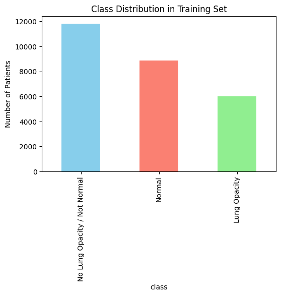

```python
plt.figure(figsize=(6,4))
class_counts = class_info_df["class"].value_counts()
class_counts.plot(kind="bar", color=["skyblue", "salmon", "lightgreen"])
plt.title("Class Distribution in Training Set")
plt.ylabel("Number of Patients")
plt.xticks(rotation=90)
plt.show()
```

```python
class_info_df["class"].value_counts()
```

| class | count |
| --- | --- |
| No Lung Opacity / Not Normal | 11821 |
| Normal | 8851 |
| Lung Opacity | 6012 |

**dtype:** int64

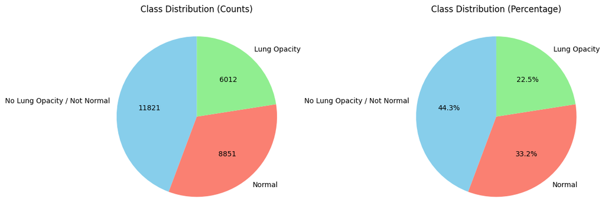

```python
colors = ["skyblue", "salmon", "lightgreen"]

# Create subplots
fig, axes = plt.subplots(1, 2, figsize=(12, 6))

# Pie chart 1: Counts
axes[0].pie(
    class_counts,
    labels=class_counts.index,
    autopct=lambda p: f'{int(p*sum(class_counts)/100)}',  # show counts
    colors=colors,
    startangle=90   # 🔹 same start angle
)
axes[0].set_title("Class Distribution (Counts)")

# Pie chart 2: Percentages
axes[1].pie(
    class_counts,
    labels=class_counts.index,
    autopct='%1.1f%%',
    colors=colors,
    startangle=90   # 🔹 same start angle
)
axes[1].set_title("Class Distribution (Percentage)")

plt.tight_layout()
plt.show()
```

#### **Observations:**

- The dataset is imbalanced, with "No Lung Opacity / Not Normal" having nearly double the samples compared to "Lung Opacity."
- Such imbalance may bias the model towards the majority class, so techniques like class weighting, data augmentation, or oversampling minority classes may be needed during training.

### **Visualization Support Function**

```python
# Function to visualize image from ZIP

def visualize_sample_from_zip(zip_path, patient_id=None, cls=None, annotations=None):
    with zipfile.ZipFile(zip_path, 'r') as zip_ref:
        if patient_id:
            matches = [name for name in zip_ref.namelist() if patient_id in name]
            if not matches:
                print(f"No file found for {patient_id}")
                return
            file_to_read = matches[0]
        else:
            # Random file for test set
            file_to_read = random.choice(zip_ref.namelist())

        try:
            with zip_ref.open(file_to_read) as f:
                dicom_data = pydicom.dcmread(BytesIO(f.read()), force=True)
            img = dicom_data.pixel_array
        except Exception as e:
            print(f"Skipping {file_to_read}: {e}")
            return

        plt.imshow(img, cmap='gray')
        title = f"{'Train' if patient_id else 'Test'} Image - {patient_id or file_to_read}"
        plt.title(title)

        # Add bounding boxes if annotations exist
        if cls == "Lung Opacity" and annotations is not None and len(annotations) > 0:
            for (x, y, w, h) in annotations:
                plt.gca().add_patch(plt.Rectangle(
                    (x, y), w, h, fill=False, color="red", linewidth=2
                ))
        plt.axis('off')
        plt.show()
```

### **Train Samples Visualization**

```
TRAIN IMAGE SAMPLES


Class: No Lung Opacity / Not Normal, Patient ID: 719dd825-dd41-46f9-a59c-7385d4576196
```

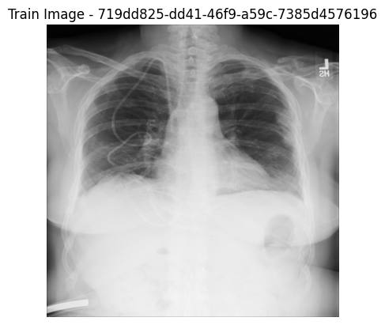

```
Class: Normal, Patient ID: ce774f35-6a80-446f-909d-040a84419b18
```

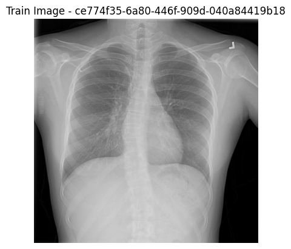

```
Class: Lung Opacity, Patient ID: f530bed2-b5bf-4240-892d-ced0140d1a8e
```

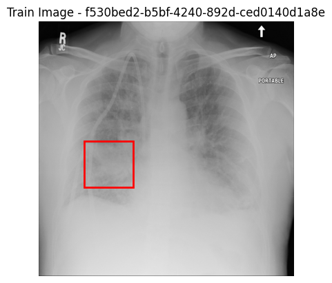

```python
# Train samples visualization
print("TRAIN IMAGE SAMPLES")
for cls in class_info_df['class'].unique():
    sample_pid = random.choice(class_info_df[class_info_df["class"] == cls]["patientId"].values)
    if cls == "Lung Opacity":
        annots = labels_df[labels_df["patientId"] == sample_pid][["x", "y", "width", "height"]].values
    else:
        annots = None
    print(f"\n\nClass: {cls}, Patient ID: {sample_pid}")
    visualize_sample_from_zip(train_zip_path, sample_pid, cls, annots)
```

### **Test Samples Visualization**

```
TEST IMAGE SAMPLES
```

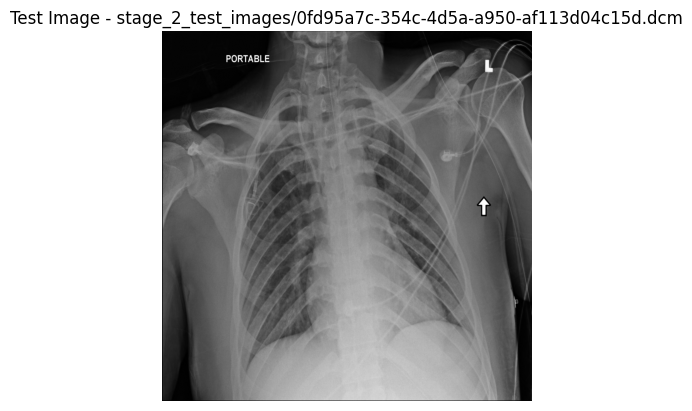

```
Skipping __MACOSX/stage_2_test_images/._2f235782-b322-4685-b644-e96dc480f0d7.dcm: Unable to decode the pixel data as the dataset's 'file_meta' has no (0002,0010) 'Transfer Syntax UID' element
```

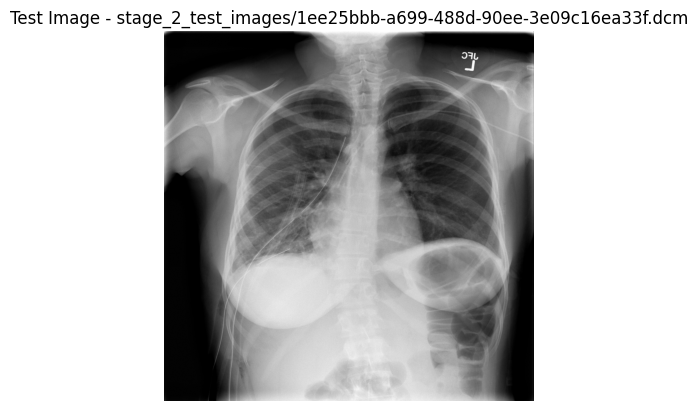

```python
# Test samples visualization
print("\nTEST IMAGE SAMPLES")
for _ in range(3):  # Show 3 random test samples
    visualize_sample_from_zip(test_zip_path)
```

## **Step 5:** **Display Images With Bounding Box**

### **Display Train Images With Bounding Box**

```python
def get_image_from_zip(zip_path, patient_id):
    """Read DICOM image from ZIP and return as numpy array."""
    with zipfile.ZipFile(zip_path, 'r') as zip_ref:
        matches = [name for name in zip_ref.namelist() if patient_id in name]
        if not matches:
            return None
        file_name = matches[0]
        try:
            with zip_ref.open(file_name) as f:
                dicom_data = pydicom.dcmread(BytesIO(f.read()), force=True)
            return dicom_data.pixel_array
        except:
            return None
```

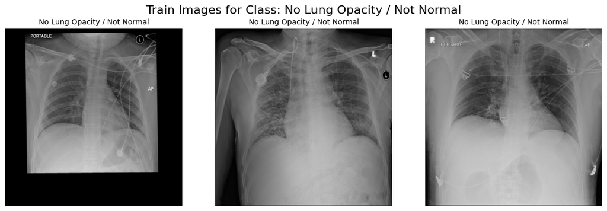

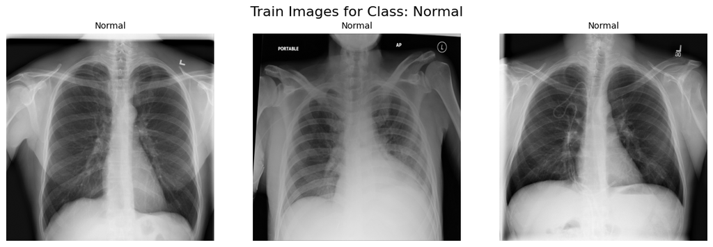

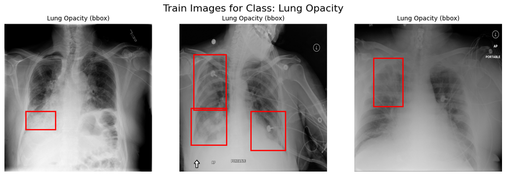

```python
# --- TRAIN IMAGES ---
train_classes = class_info_df['class'].unique()

for cls in train_classes:
    sample_ids = random.sample(
        list(class_info_df[class_info_df['class'] == cls]['patientId']), 3
    )
    imgs = []
    titles = []

    for pid in sample_ids:
        img = get_image_from_zip(train_zip_path, pid)
        if img is None:  # Skip missing images
            continue
        imgs.append(img)
        titles.append(cls)

    # Create subplot grid dynamically (only for available images)
    fig, axes = plt.subplots(1, len(imgs), figsize=(12, 4))
    if len(imgs) == 1:
        axes = [axes]  # keep iterable

    for ax, img, pid in zip(axes, imgs, sample_ids):
        ax.imshow(img, cmap='gray')
        ax.axis('off')
        title = cls

        # Add bounding boxes for Lung Opacity
        if cls == "Lung Opacity":
            annots = labels_df[labels_df["patientId"] == pid][["x", "y", "width", "height"]].values
            for (x, y, w, h) in annots:
                ax.add_patch(
                    plt.Rectangle((x, y), w, h, fill=False, color="red", linewidth=2)
                )
            title += " (bbox)"
        ax.set_title(title, fontsize=10)

    plt.suptitle(f"Train Images for Class: {cls}", fontsize=16)
    plt.tight_layout()
    plt.show()
```

### **Display Test Images Without Bounding Box**

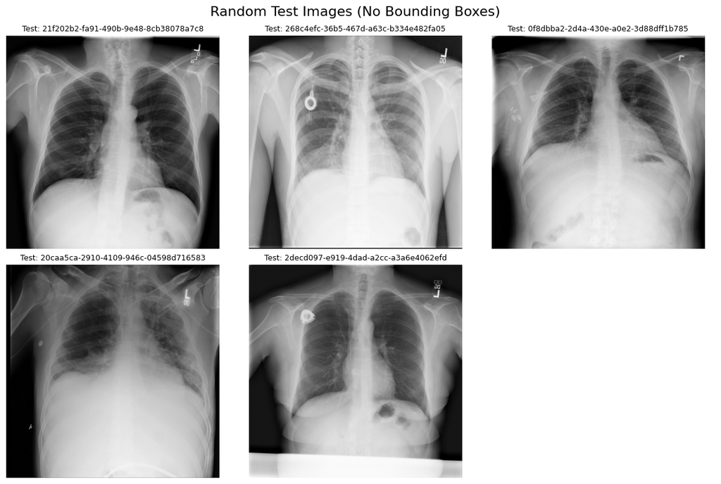

```python
# --- TEST IMAGES ---
with zipfile.ZipFile(test_zip_path, 'r') as test_zip:
    test_files = [f for f in test_zip.namelist() if f.lower().endswith(".dcm")]
    sample_test = random.sample(test_files, 6)  # Pick 6 random test files

# Store valid images & IDs
imgs, ids = [], []
for file_name in sample_test:
    patient_id = file_name.split("/")[-1].replace(".dcm", "")
    img = get_image_from_zip(test_zip_path, patient_id)
    if img is not None:  # Only keep valid images
        imgs.append(img)
        ids.append(patient_id)

# Adjust subplot grid based on available images
rows, cols = 2, 3
fig, axes = plt.subplots(rows, cols, figsize=(12, 8))

# Flatten axes for easier iteration
axes = axes.flatten()

for ax, img, pid in zip(axes, imgs, ids):
    ax.imshow(img, cmap='gray')
    ax.axis('off')
    ax.set_title(f"Test: {pid}", fontsize=9)

# Hide unused axes (if < 6 images are available)
for ax in axes[len(imgs):]:
    ax.axis('off')

plt.suptitle("Random Test Images (No Bounding Boxes)", fontsize=16)
plt.tight_layout()
plt.show()
```

### **Observations:**

- A common issue in medical imaging datasets is that some images may be missing or not found. To handle this, our function is designed to skip missing images gracefully instead of breaking the pipeline.
- Possible Causes for Skipped Images:
  - Patient IDs listed in metadata but missing from the ZIP archive.
  - File name mismatches between the metadata CSV and actual DICOM/PNG files.
  - Corrupted or unreadable image files.
  - Mixed file formats (e.g., .dcm, .png, .jpg) not handled consistently.
  - DICOM parsing issues caused by unusual compression or encoding.

## **Step 6: Design, Train And Test Basic CNN Models For Classification**

### **Model Design and Compilation**

```python
# Define model parameters
IMG_WIDTH = 224
IMG_HEIGHT = 224
IMG_CHANNELS = 3
input_shape = (IMG_WIDTH, IMG_HEIGHT, IMG_CHANNELS)

# Build the CNN model
model = Sequential([
    # Convolutional Block 1
    Conv2D(32, (3, 3), activation='relu', input_shape=input_shape),
    MaxPooling2D((2, 2)),

    # Convolutional Block 2
    Conv2D(64, (3, 3), activation='relu'),
    MaxPooling2D((2, 2)),

    # Convolutional Block 3
    Conv2D(128, (3, 3), activation='relu'),
    MaxPooling2D((2, 2)),

    # Flatten the feature maps to prepare for the dense layers
    Flatten(),

    # Fully Connected Layers
    Dense(512, activation='relu'),
    Dropout(0.5), # Add dropout for regularization to prevent overfitting
    Dense(1, activation='sigmoid') # Final output layer for binary classification
])

# Compile the model
model.compile(optimizer=Adam(learning_rate=0.0001),
              loss='binary_crossentropy',
              metrics=['accuracy'])

# Display the model's architecture
model.summary()
```

```
Model: "sequential"
```

```
┏━━━━━━━━━━━━━━━━━━━━━━━━━━━━━━━━━┳━━━━━━━━━━━━━━━━━━━━━━━━┳━━━━━━━━━━━━━━━┓
┃ Layer (type)                    ┃ Output Shape           ┃       Param # ┃
┡━━━━━━━━━━━━━━━━━━━━━━━━━━━━━━━━━╇━━━━━━━━━━━━━━━━━━━━━━━━╇━━━━━━━━━━━━━━━┩
│ conv2d (Conv2D)                 │ (None, 222, 222, 32)   │           896 │
├─────────────────────────────────┼────────────────────────┼───────────────┤
│ max_pooling2d (MaxPooling2D)    │ (None, 111, 111, 32)   │             0 │
├─────────────────────────────────┼────────────────────────┼───────────────┤
│ conv2d_1 (Conv2D)               │ (None, 109, 109, 64)   │        18,496 │
├─────────────────────────────────┼────────────────────────┼───────────────┤
│ max_pooling2d_1 (MaxPooling2D)  │ (None, 54, 54, 64)     │             0 │
├─────────────────────────────────┼────────────────────────┼───────────────┤
│ conv2d_2 (Conv2D)               │ (None, 52, 52, 128)    │        73,856 │
├─────────────────────────────────┼────────────────────────┼───────────────┤
│ max_pooling2d_2 (MaxPooling2D)  │ (None, 26, 26, 128)    │             0 │
├─────────────────────────────────┼────────────────────────┼───────────────┤
│ flatten (Flatten)               │ (None, 86528)          │             0 │
├─────────────────────────────────┼────────────────────────┼───────────────┤
│ dense (Dense)                   │ (None, 512)            │    44,302,848 │
├─────────────────────────────────┼────────────────────────┼───────────────┤
│ dropout (Dropout)               │ (None, 512)            │             0 │
├─────────────────────────────────┼────────────────────────┼───────────────┤
│ dense_1 (Dense)                 │ (None, 1)              │           513 │
└─────────────────────────────────┴────────────────────────┴───────────────┘
```

```
 Total params: 44,396,609 (169.36 MB)
```

```
 Trainable params: 44,396,609 (169.36 MB)
```

```
 Non-trainable params: 0 (0.00 B)
```

### **Data Preparation for Training**

```python
def data_generator(df, zip_file, batch_size=32, target_size=(224, 224)):
    """
    A generator that yields preprocessed images and labels in batches.
    """
    while True:
        # Get a random batch of data
        batch_df = df.sample(n=batch_size)

        images = []
        labels = []

        for _, row in batch_df.iterrows():
            patient_id = row['patientId']
            label = row['Target']

            # Read and process the DICOM image
            img = read_dicom_image(patient_id, zip_file, target_size)
            if img is not None:
                images.append(img)
                labels.append(label)

        # Normalize images to the 0-1 range and yield as tensors
        images = tf.convert_to_tensor(np.array(images).astype('float32') / 255.0)
        labels = tf.convert_to_tensor(np.array(labels))

        yield images, labels
```

### **Training and Testing the model**

```python
# Assuming you have already created train_df and val_df
# from a previous step (train_test_split)

# Define batch size
BATCH_SIZE = 32

# Open the zip file once
archive = zipfile.ZipFile(train_zip_path, 'r')

# Create the data generators for training and validation
train_gen = data_generator(train_df, archive, batch_size=BATCH_SIZE)
val_gen = data_generator(val_df, archive, batch_size=BATCH_SIZE)

# Calculate steps per epoch to ensure a full pass through the data
train_steps = len(train_df) // BATCH_SIZE
val_steps = len(val_df) // BATCH_SIZE

# Train the model
history = model.fit(
    train_gen,
    steps_per_epoch=train_steps,
    epochs=10, # Number of epochs to train for
    validation_data=val_gen,
    validation_steps=val_steps
)

# Evaluate the model on the validation set
# Re-create the generator for evaluation to ensure data is read from the beginning
val_gen_eval = data_generator(val_df, archive, batch_size=BATCH_SIZE)
loss, accuracy = model.evaluate(val_gen_eval, steps=val_steps)
print(f"Validation Loss: {loss:.4f}")
print(f"Validation Accuracy: {accuracy:.4f}")

# After training, it's good practice to close the zip file
archive.close()
```

```
667/667 ━━━━━━━━━━━━━━━━━━━━ 396s 581ms/step - accuracy: 0.7800 - loss: 0.4818 - val_accuracy: 0.7973 - val_loss: 0.4349
667/667 ━━━━━━━━━━━━━━━━━━━━ 317s 476ms/step - accuracy: 0.8119 - loss: 0.4223 - val_accuracy: 0.8016 - val_loss: 0.4186
667/667 ━━━━━━━━━━━━━━━━━━━━ 323s 485ms/step - accuracy: 0.8066 - loss: 0.4170 - val_accuracy: 0.8131 - val_loss: 0.4081
667/667 ━━━━━━━━━━━━━━━━━━━━ 318s 477ms/step - accuracy: 0.8139 - loss: 0.4109 - val_accuracy: 0.8061 - val_loss: 0.4285
667/667 ━━━━━━━━━━━━━━━━━━━━ 311s 468ms/step - accuracy: 0.8179 - loss: 0.3993 - val_accuracy: 0.8053 - val_loss: 0.4217
667/667 ━━━━━━━━━━━━━━━━━━━━ 318s 477ms/step - accuracy: 0.8271 - loss: 0.3802 - val_accuracy: 0.7989 - val_loss: 0.4269
667/667 ━━━━━━━━━━━━━━━━━━━━ 317s 476ms/step - accuracy: 0.8385 - loss: 0.3620 - val_accuracy: 0.8151 - val_loss: 0.4252
667/667 ━━━━━━━━━━━━━━━━━━━━ 316s 474ms/step - accuracy: 0.8510 - loss: 0.3312 - val_accuracy: 0.8080 - val_loss: 0.4351
667/667 ━━━━━━━━━━━━━━━━━━━━ 313s 469ms/step - accuracy: 0.8637 - loss: 0.3175 - val_accuracy: 0.8001 - val_loss: 0.4593
667/667 ━━━━━━━━━━━━━━━━━━━━ 317s 476ms/step - accuracy: 0.8815 - loss: 0.2803 - val_accuracy: 0.8037 - val_loss: 0.4726
166/166 ━━━━━━━━━━━━━━━━━━━━ 59s 358ms/step - accuracy: 0.8078 - loss: 0.4717
Validation Loss: 0.4733
Validation Accuracy: 0.8063
```

### **Save the Model**

```python
#Save Model
model.save('basic_cnn_model.keras')
print("Basic CNN Saved Successfully!")
```

```
Basic CNN Saved Successfully!
```

### **Visualizing the Performance using the saved Model**

```python
from tensorflow.keras.models import load_model

# Load the model back
model = load_model('basic_cnn_model.keras')
print("Model loaded successfully!")
```

```
Model loaded successfully!
```

```python
# Get validation data and labels from the generator
# Re-create the generator to get a fresh batch of data
archive_eval = zipfile.ZipFile(train_zip_path, 'r') # Re-open the zip file for evaluation
# Create a generator to get the entire validation set as a single batch
val_gen_eval = data_generator(val_df, archive_eval, batch_size=len(val_df))
val_images, val_labels = next(val_gen_eval)
archive_eval.close() # Close the zip file after getting the data


# Get prediction probabilities
y_pred_probs = model.predict(val_images)

# Convert probabilities to binary labels (0 = No Pneumonia, 1 = Pneumonia)
y_pred = (y_pred_probs > 0.5).astype("int32")
```

```
167/167 ━━━━━━━━━━━━━━━━━━━━ 8s 27ms/step
```

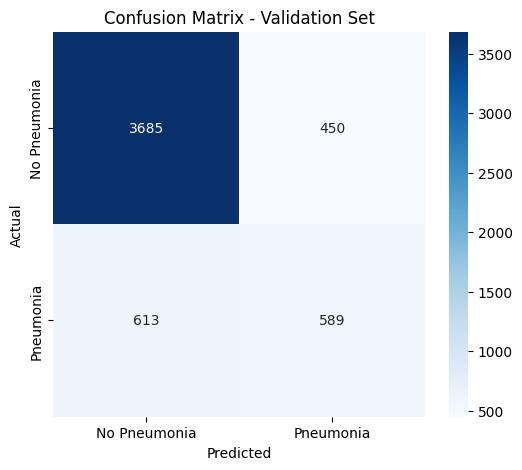

```
Classification Report:

              precision    recall  f1-score   support

No Pneumonia       0.86      0.89      0.87      4135
   Pneumonia       0.57      0.49      0.53      1202

    accuracy                           0.80      5337
   macro avg       0.71      0.69      0.70      5337
weighted avg       0.79      0.80      0.80      5337
```

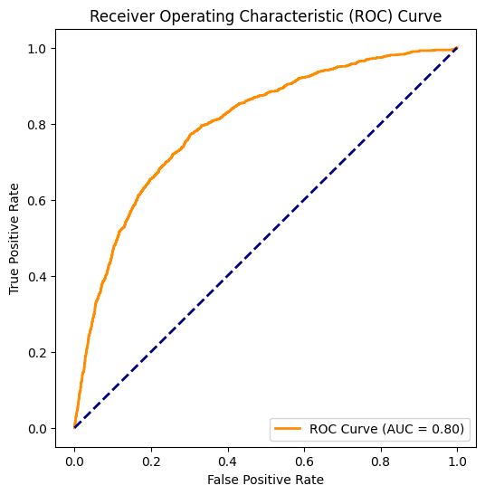

```python
from sklearn.metrics import classification_report, confusion_matrix, roc_curve, auc
import matplotlib.pyplot as plt
import seaborn as sns

# Get validation data and labels from the generator
# These variables are expected to be defined in the previous cell (ZEcJ-0ulUl65)

# -------------------------------
# Confusion Matrix
# -------------------------------
cm = confusion_matrix(val_labels, y_pred)

plt.figure(figsize=(6,5))
sns.heatmap(cm, annot=True, fmt="d", cmap="Blues",
            xticklabels=["No Pneumonia","Pneumonia"],
            yticklabels=["No Pneumonia","Pneumonia"])
plt.xlabel("Predicted")
plt.ylabel("Actual")
plt.title("Confusion Matrix - Validation Set")
plt.show()

# -------------------------------
# Classification Report
# -------------------------------
print("Classification Report:\n")
print(classification_report(val_labels, y_pred, target_names=["No Pneumonia","Pneumonia"]))

# -------------------------------
# ROC Curve
# -------------------------------
fpr, tpr, thresholds = roc_curve(val_labels, y_pred_probs)
roc_auc = auc(fpr, tpr)

plt.figure(figsize=(6,6))
plt.plot(fpr, tpr, color="darkorange", lw=2, label=f"ROC Curve (AUC = {roc_auc:.2f})")
plt.plot([0,1], [0,1], color="navy", lw=2, linestyle="--")
plt.xlabel("False Positive Rate")
plt.ylabel("True Positive Rate")
plt.title("Receiver Operating Characteristic (ROC) Curve")
plt.legend(loc="lower right")
plt.show()
```

**Observations:**

**Feature Learning:** The model appears to capture relevant features (such as lung opacities) early in training, which aligns with its strong ability to classify No Pneumonia cases.

**Generalization Gap:** A sharp divergence between training and validation performance after Epoch 3 suggests overfitting — the model is memorizing training data instead of learning robust, generalizable patterns.

**Model Complexity:** The presence of a very large fully connected layer (~44M parameters) increases overfitting risk, especially with an imbalanced dataset where pneumonia cases are fewer.

**Performance Trade-off:** While the model achieves good overall accuracy (80%) and AUC (0.80), recall for pneumonia (0.49) is significantly lower, showing that overfitting disproportionately impacts minority-class detection.

**Clinical Implication:** High false negatives (missed pneumonia cases) are concerning in a healthcare setting, meaning the current model is safer for ruling out pneumonia than for confidently diagnosing it.

### **Key Insights and Observation**

**Next Steps and Recommendations**

- To mitigate overfitting and improve your model's performance, consider these strategies:

  **Early Stopping:** We should stop training when the validation loss starts to increase. Based on these results, training past Epoch 3 doesn't improve performance on unseen data. We can implement a Keras Callback for early stopping to automate this process.

  **Regularization:** The model has a dropout layer, but we may need more aggressive regularization. We can consider adding more dropout layers or increasing the dropout rate. We can also introduce L1 or L2 regularization to your convolutional or dense layers.

  **Data Augmentation:** We can apply diverse data augmentation techniques (e.g., rotations, shifts, zooms) to make the training data more varied and help the model generalize better.